# R Notebook

# **Курсовой проект к курсу “Язык R для анализа данных”**

1. Проверить статистическую гипотезу о различии веса среди мужчин и женщин.

   Рассчитать нужный объем выборки для мощности теста 90%.

   Выбрать критерий и обосновать его применение

   Провести тест и интерпретировать результат.

   Вывод представить в виде доверительного интервала в процентах для размера эффекта
2. Провести двухфакторный дисперсионный анализ.

   Проверить влияние на вес пола и приема алкоголя.

   В рамках этой темы проверить условия применимости, провести анализ, интерпретировать результат.

## 1. Загрузим необходимые библиотеки

```r
library(asbio)
library(BSDA)
library(dplyr)
library(effsize)
library(pwr)
library(rafalib)
library(rio)
```

## 2. EDA - Произведем разведочный анализ данных

Загрузим датасет

```r
ds.cardio <- import("cardio_train.csv")
head(ds.cardio)
```

|  | id | age | gender | height | weight | ap_hi | ap_lo | cholesterol | gluc | smoke | alco | active | cardio |
| --- | --- | --- | --- | --- | --- | --- | --- | --- | --- | --- | --- | --- | --- |
| 1 | 0 | 18393 | 2 | 168 | 62 | 110 | 80 | 1 | 1 | 0 | 0 | 1 | 0 |
| 2 | 1 | 20228 | 1 | 156 | 85 | 140 | 90 | 3 | 1 | 0 | 0 | 1 | 1 |
| 3 | 2 | 18857 | 1 | 165 | 64 | 130 | 70 | 3 | 1 | 0 | 0 | 0 | 1 |
| 4 | 3 | 17623 | 2 | 169 | 82 | 150 | 100 | 1 | 1 | 0 | 0 | 1 | 1 |
| 5 | 4 | 17474 | 1 | 156 | 56 | 100 | 60 | 1 | 1 | 0 | 0 | 0 | 0 |
| 6 | 8 | 21914 | 1 | 151 | 67 | 120 | 80 | 2 | 2 | 0 | 0 | 0 | 0 |

Посмотрим на структуру датасета

```r
str(ds.cardio)
```

```
## 'data.frame':    70000 obs. of  13 variables:
##  $ id         : int  0 1 2 3 4 8 9 12 13 14 ...
##  $ age        : int  18393 20228 18857 17623 17474 21914 22113 22584 17668 19834 ...
##  $ gender     : int  2 1 1 2 1 1 1 2 1 1 ...
##  $ height     : int  168 156 165 169 156 151 157 178 158 164 ...
##  $ weight     : num  62 85 64 82 56 67 93 95 71 68 ...
##  $ ap_hi      : int  110 140 130 150 100 120 130 130 110 110 ...
##  $ ap_lo      : int  80 90 70 100 60 80 80 90 70 60 ...
##  $ cholesterol: int  1 3 3 1 1 2 3 3 1 1 ...
##  $ gluc       : int  1 1 1 1 1 2 1 3 1 1 ...
##  $ smoke      : int  0 0 0 0 0 0 0 0 0 0 ...
##  $ alco       : int  0 0 0 0 0 0 0 0 0 0 ...
##  $ active     : int  1 1 0 1 0 0 1 1 1 0 ...
##  $ cardio     : int  0 1 1 1 0 0 0 1 0 0 ...
```

Преобразуем возвраст в днях в возраст в годах

```r
ds.cardio <- ds.cardio %>% mutate(age_years=(trunc(age/365)))
head(ds.cardio)
```

|  | id | age | gender | height | weight | ap_hi | ap_lo | cholesterol | gluc | smoke | alco | active | cardio | age_years |
| --- | --- | --- | --- | --- | --- | --- | --- | --- | --- | --- | --- | --- | --- | --- |
| 1 | 0 | 18393 | 2 | 168 | 62 | 110 | 80 | 1 | 1 | 0 | 0 | 1 | 0 | 50 |
| 2 | 1 | 20228 | 1 | 156 | 85 | 140 | 90 | 3 | 1 | 0 | 0 | 1 | 1 | 55 |
| 3 | 2 | 18857 | 1 | 165 | 64 | 130 | 70 | 3 | 1 | 0 | 0 | 0 | 1 | 51 |
| 4 | 3 | 17623 | 2 | 169 | 82 | 150 | 100 | 1 | 1 | 0 | 0 | 1 | 1 | 48 |
| 5 | 4 | 17474 | 1 | 156 | 56 | 100 | 60 | 1 | 1 | 0 | 0 | 0 | 0 | 47 |
| 6 | 8 | 21914 | 1 | 151 | 67 | 120 | 80 | 2 | 2 | 0 | 0 | 0 | 0 | 60 |

Удалим колонки ID и Age так как они нам не понадобятся

```r
ds.cardio <- ds.cardio[, -c(1, 2)]
head(ds.cardio)
```

|  | gender | height | weight | ap_hi | ap_lo | cholesterol | gluc | smoke | alco | active | cardio | age_years |
| --- | --- | --- | --- | --- | --- | --- | --- | --- | --- | --- | --- | --- |
| 1 | 2 | 168 | 62 | 110 | 80 | 1 | 1 | 0 | 0 | 1 | 0 | 50 |
| 2 | 1 | 156 | 85 | 140 | 90 | 3 | 1 | 0 | 0 | 1 | 1 | 55 |
| 3 | 1 | 165 | 64 | 130 | 70 | 3 | 1 | 0 | 0 | 0 | 1 | 51 |
| 4 | 2 | 169 | 82 | 150 | 100 | 1 | 1 | 0 | 0 | 1 | 1 | 48 |
| 5 | 1 | 156 | 56 | 100 | 60 | 1 | 1 | 0 | 0 | 0 | 0 | 47 |
| 6 | 1 | 151 | 67 | 120 | 80 | 2 | 2 | 0 | 0 | 0 | 0 | 60 |

```r
dim(ds.cardio)
```

```
## [1] 70000    12
```

Проверим есть ли некоректные данные по верхнему и нижнему давлению

```r
err.data.qty = nrow(ds.cardio[ds.cardio$ap_hi < ds.cardio$ap_lo,])
```

Если некоректные данные присутствуют то удалим их

```r
if (err.data.qty > 0) {
  ds.cardio <- ds.cardio[ds.cardio$ap_hi > ds.cardio$ap_lo,]
  dim(ds.cardio)
}
```

```
## [1] 68764    12
```

Создадим датасет который содержит в себе давление с нижней границей не менее 60 и 80 и с верхней границей не более 140 и 190

```r
dsc.clean <- ds.cardio[ds.cardio$ap_hi > 80 & ds.cardio$ap_hi < 190,]
dsc.clean <- dsc.clean[dsc.clean$ap_lo > 60 & dsc.clean$ap_lo < 140,]
dim(dsc.clean)
```

```
## [1] 65568    12
```

Посмотрим на среднее и стандартное отклонение для показателей давления

```r
mean(dsc.clean$ap_lo)
```

```
## [1] 82.13307
```

```r
sd(dsc.clean$ap_lo)
```

```
## [1] 8.261823
```

```r
mean(dsc.clean$ap_hi)
```

```
## [1] 127.3339
```

```r
sd(dsc.clean$ap_hi)
```

```
## [1] 15.42975
```

Построим боксплот

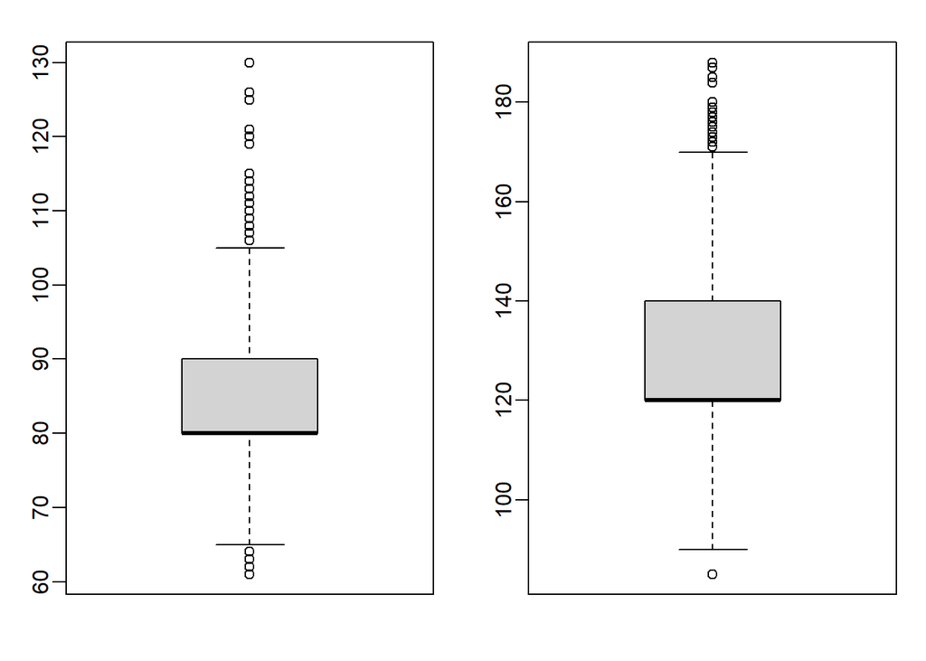

```r
mypar(1, 2)
boxplot(dsc.clean$ap_lo)
boxplot(dsc.clean$ap_hi)
```

Построим гистограмму

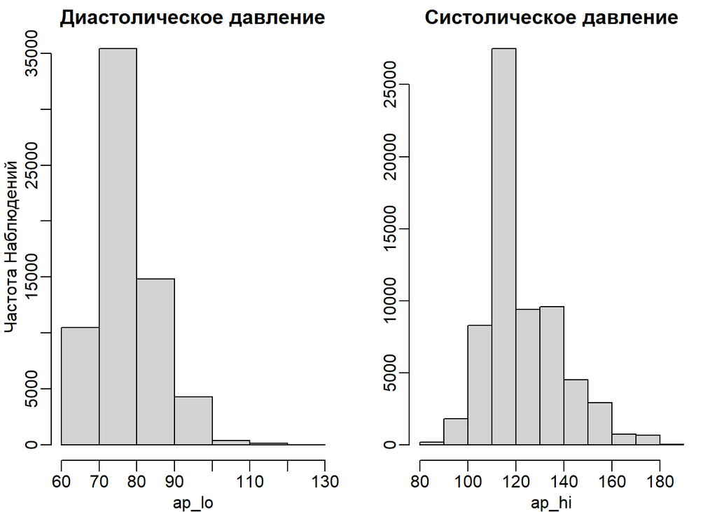

```r
mypar(1, 2)
hist(dsc.clean$ap_lo, main="Диастолическое давление", xlab = "ap_lo", ylab="Частота Наблюдений", breaks=6)
hist(dsc.clean$ap_hi, main="Систолическое давление", xlab = "ap_hi", ylab="", breaks=10)
```

Проверим на близость к нормальному распределению показателей давления

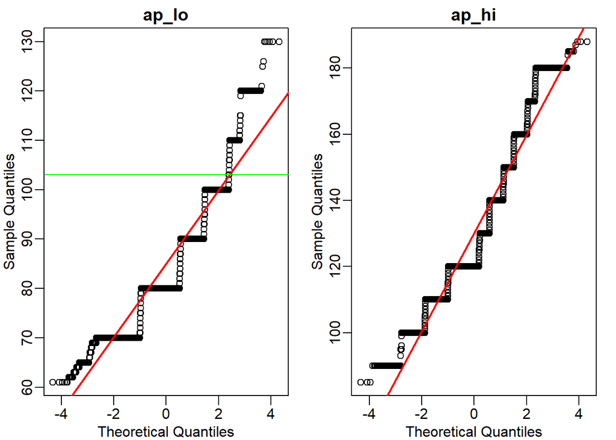

```r
mypar(1, 2)
qqnorm(dsc.clean$ap_lo, main="ap_lo")
qqline(dsc.clean$ap_lo, col="red", lwd=2)
abline(h=103, col="green")
qqnorm(dsc.clean$ap_hi, main="ap_hi")
qqline(dsc.clean$ap_hi, col="red", lwd=2)
```

Теперь показатели давления близки к нормальному распределению и очевидно что в процессе измерений показатели округлялись

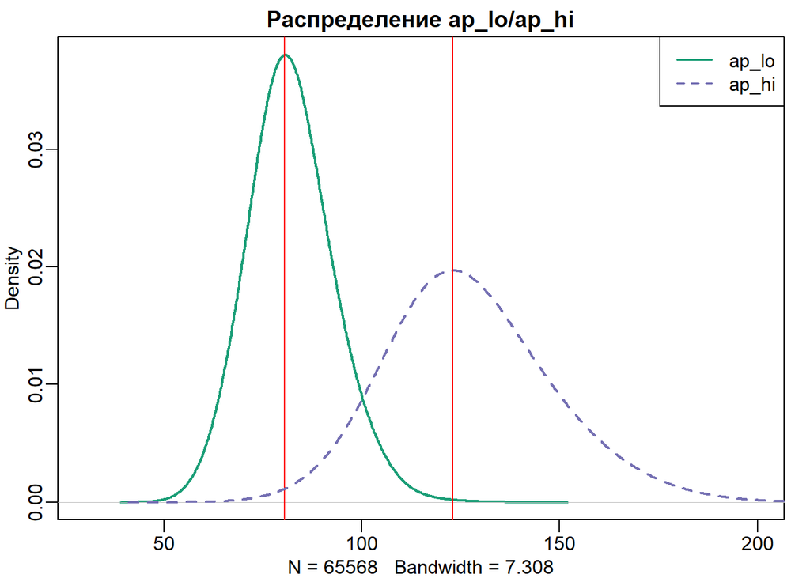

```r
mypar(1, 1)
plot(density(dsc.clean$ap_lo, adjust = 10), col=1, xlim=c(30, 200), lwd=2, main="Распределение ap_lo/ap_hi")
abline(v=80.5, col="red")
lines(density(dsc.clean$ap_hi, adjust = 10), col=3, lwd=2, lty=2)
abline(v=123, col="red")
legend("topright",c("ap_lo","ap_hi"), col=c(1,3), lwd=c(1.5, 1.5), lty = c(1,2))
```

Посмотрим на показатели веса

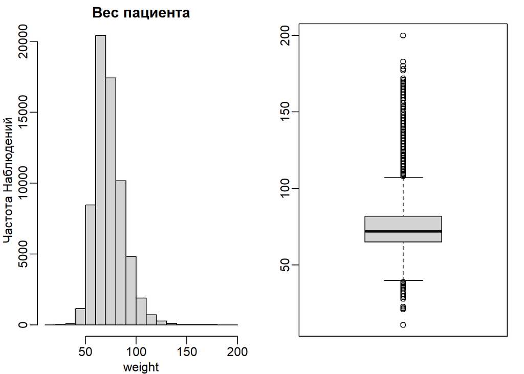

```r
mypar(1, 2)
hist(dsc.clean$weight, main="Вес пациента", xlab = "weight", ylab="Частота Наблюдений")
boxplot(dsc.clean$weight)
```

Построим боксплот разбив на группы: мужчины и женщины

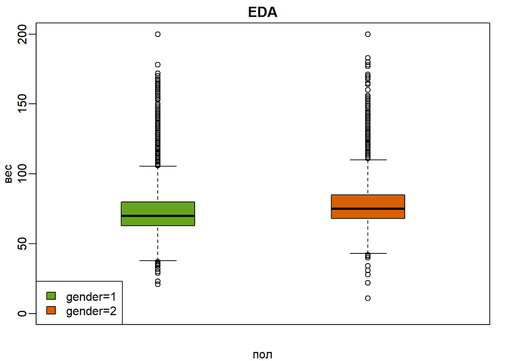

```r
mypar(1, 1)
boxplot(dsc.clean$weight ~ dsc.clean$gender, data=dsc.clean,
        boxwex=0.7, at=1,
        subset=dsc.clean$gender == "1", col="5", main="EDA",
        xlab="пол", ylab="вес",
        xlim=c(0.5, 2.5), ylim=c(0, 200))
boxplot(dsc.clean$weight ~ dsc.clean$gender, data=dsc.clean, add=TRUE,
        boxwex=0.7, at=2,
        subset=dsc.clean$gender == "2", col="2")
legend("bottomleft", c("gender=1", "gender=2"), fill=c("5", "2"))
```

Как и ожидалось вес женщин меньше чем вес мужчин

Можно исключить из датасета вес более 150 и менее 20 так более высоки веса не сильно повлияют на анализ

```r
dsc.clean <- dsc.clean[dsc.clean$weight > 20 & dsc.clean$weight < 150,]
dim(dsc.clean)
```

```
## [1] 65503    12
```

Проверим на нормальность распределение веса

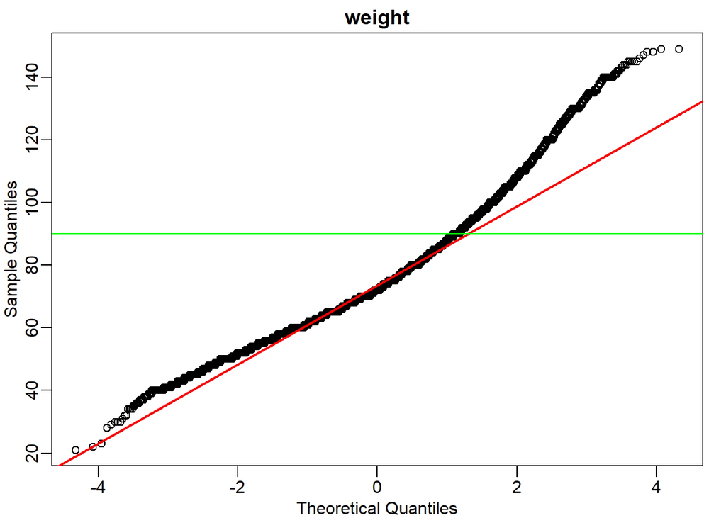

```r
mypar(1, 1)
qqnorm(dsc.clean$weight, main="weight")
qqline(dsc.clean$weight, col="red", lwd=2)
abline(h=90, col="green")
```

В целом показатели веса близки к нормальному распределению.

Посмотрим на наличие дисбаланса выборок мужчин и женщин:

```r
table(dsc.clean$gender)
```

```
##
##     1     2
## 42391 23112
```

Дисбаланс присутствует.

Посмотрим нв дисбаланс в отнешении веса:

```r
table(dsc.clean$gender, dsc.clean$weight)
```

```
##
##       21   22   23   28   29   30   31   32   34   35 35.45   36   37   38   39
##   1    1    0    1    0    1    3    0    2    3    2     1    3    6    7    6
##   2    0    1    0    1    0    0    1    0    1    0     0    0    0    0    0
##
##       40   41   42 42.2   43   44   45   46   47   48   49   50   51 51.5   52
##   1   27   28   35    1   43   49   87   64   86  140  116  348  195    1  372
##   2    5    2    1    0    2    3   15   10    7   17   27   74   44    0  103
##
##     52.3   53 53.2 53.3 53.5 53.6 53.67 53.9   54 54.35 54.5   55 55.2 55.4
##   1    1  301    1    1    1    1     1    1  412     1    2  536    1    1
##   2    0   68    0    0    0    0     0    0   95     0    0  142    0    0
##
##     55.6   56 56.2   57 57.6 57.8   58 58.7 58.8   59 59.5 59.8   60 60.1 60.2
##   1    1  704    2  520    1    2  967    1    1  728    2    1 1855    1    1
##   2    0  186    0  118    0    0  253    0    0  209    0    0  633    0    0
##
##     60.5   61 61.2 61.3 61.5   62 62.2 62.3 62.4 62.5 62.7   63 63.4 63.8 63.82
##   1    0  656    1    0    2 1277    1    1    1    1    0 1090    1    0     1
##   2    1  238    0    1    0  451    0    1    1    1    1  414    0    1     0
##
##       64 64.1 64.3 64.5 64.7 64.8   65 65.3 65.5   66 66.3 66.4 66.5   67 67.3
##   1 1074    0    0    4    1    0 2623    1    1  944    1    1    2 1063    0
##   2  399    1    1    1    0    1 1017    0    1  357    0    0    1  452    1
##
##     67.5 67.8 67.9   68 68.2 68.3 68.4 68.5 68.9   69 69.5 69.8   70 70.2 70.3
##   1    1    0    2 1784    1    0    1    4    1 1362    4    1 2226    2    0
##   2    1    1    0  880    1    1    0    2    0  711    1    1 1354    0    1
##
##     70.5 70.7 70.8   71 71.2 71.3 71.5   72 72.1 72.5 72.8   73 73.2 73.5 73.8
##   1    2    1    0  880    0    2    2 1352    1    3    1  879    1    0    1
##   2    0    0    1  480    1    0    1  841    1    0    0  498    2    1    0
##
##       74 74.2 74.3 74.5   75 75.2 75.5 75.6   76 76.5 76.7 76.8   77   78 78.2
##   1 1053    1    0    1 1534    1    1    0  853    2    1    0  558 1193    1
##   2  706    1    1    0 1070    0    1    1  588    0    0    1  362  791    1
##
##     78.5   79 79.5 79.94   80 80.5 80.7 80.8   81 81.1   82 82.1 82.3 82.4 82.5
##   1    1  705    0     1 1455    2    0    1  479    0  710    0    3    0    2
##   2    0  524    2     0 1055    1    1    0  362    1  538    1    0    1    1
```

[output cut: 13 more lines]

```
##     105.5  106 106.4 106.5  107  108  109 109.5 109.7  110  111  112  113  114
##   1     1   73     1     1   57   86   59     0     1  131   24   61   36   35
##   2     0   70     0     0   52   61   45     1     0  104   36   52   35   25
##
##     114.6  115  116  117  118  119  120  121 121.3 121.8  122  123  124  125
##   1     1   51   24   33   26   17   63   10     0     1   11   18   14   23
##   2     0   64   23   19   25   14   40   12     1     0    9   14    8   15
##
##      126  127  128  129  130  131  132  133  134  135  136  137  138  139  140
##   1   16   13   10    6   27   12    5    6    6   12    9    1    4    3    7
##   2    8   10   11    9   21    1    4    4    4    9    0    1    1    2    9
##
##      141  142  143  144  145  146  147  148  149
##   1    2    2    1    1    4    1    0    1    1
##   2    2    1    1    2    1    0    1    1    1
```

Заметно что в подавляющем количестве случаев вес округлялся до целого. Измерения с показателем веса с грамами округлим так как их очень мало:

```r
dsc.clean$weight <- round(dsc.clean$weight, digits=0)
table(dsc.clean$gender, dsc.clean$weight)
```

```
##
##       21   22   23   28   29   30   31   32   34   35   36   37   38   39   40
##   1    1    0    1    0    1    3    0    2    3    3    3    6    7    6   27
##   2    0    1    0    1    0    0    1    0    1    0    0    0    0    0    5
##
##       41   42   43   44   45   46   47   48   49   50   51   52   53   54   55
##   1   28   36   43   49   87   64   86  140  116  348  195  374  303  419  538
##   2    2    1    2    3   15   10    7   17   27   74   44  103   68   95  142
##
##       56   57   58   59   60   61   62   63   64   65   66   67   68   69   70
##   1  707  520  970  730 1860  657 1283 1091 1079 2625  949 1063 1793 1363 2235
##   2  186  118  253  209  634  239  454  415  403 1018  359  453  886  711 1357
##
##       71   72   73   74   75   76   77   78   79   80   81   82   83   84   85
##   1  883 1358  881 1056 1535  856  559 1195  705 1458  480  715  555  614  893
```

[output cut: 21 more lines]

```r
head(dsc.clean)
```

|  | gender | height | weight | ap_hi | ap_lo | cholesterol | gluc | smoke | alco | active | cardio | age_years |
| --- | --- | --- | --- | --- | --- | --- | --- | --- | --- | --- | --- | --- |
| 1 | 2 | 168 | 62 | 110 | 80 | 1 | 1 | 0 | 0 | 1 | 0 | 50 |
| 2 | 1 | 156 | 85 | 140 | 90 | 3 | 1 | 0 | 0 | 1 | 1 | 55 |
| 3 | 1 | 165 | 64 | 130 | 70 | 3 | 1 | 0 | 0 | 0 | 1 | 51 |
| 4 | 2 | 169 | 82 | 150 | 100 | 1 | 1 | 0 | 0 | 1 | 1 | 48 |
| 6 | 1 | 151 | 67 | 120 | 80 | 2 | 2 | 0 | 0 | 0 | 0 | 60 |
| 7 | 1 | 157 | 93 | 130 | 80 | 3 | 1 | 0 | 0 | 1 | 0 | 60 |

Посмотрим на взаимную кореляцию веса и роста в зависимости от пола:

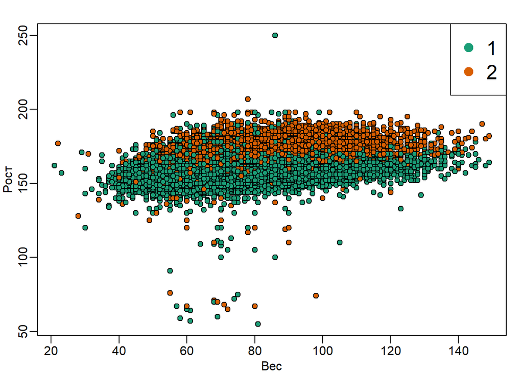

```r
mypar(1, 1)
plot(dsc.clean$weight, dsc.clean$height, pch=21,
     bg= as.numeric(factor(dsc.clean$gender)), xlab = "Вес", ylab= "Рост")
legend("topright", levels(factor(dsc.clean$gender)),col=seq(along=levels(factor(dsc.clean$gender))), pch=19,cex=1.6)
```

## 3. Провериv статистическую гипотезу о различии веса среди мужчин и женщин.

### 3.1 Убеждимся, что наблюдения независимы

В наблюдении представлены пациенты разных возрастов от 29 до 64 лет:

```r
sort(unique(dsc.clean$age_years))
```

```
##  [1] 29 30 39 40 41 42 43 44 45 46 47 48 49 50 51 52 53 54 55 56 57 58 59 60 61
## [26] 62 63 64
```

В наблюдениях представлен широкий диапазон веса пациента от 21кг до 149кг:

```r
sort(unique(dsc.clean$weight))
```

```
##   [1]  21  22  23  28  29  30  31  32  34  35  36  37  38  39  40  41  42  43
##  [19]  44  45  46  47  48  49  50  51  52  53  54  55  56  57  58  59  60  61
##  [37]  62  63  64  65  66  67  68  69  70  71  72  73  74  75  76  77  78  79
##  [55]  80  81  82  83  84  85  86  87  88  89  90  91  92  93  94  95  96  97
##  [73]  98  99 100 101 102 103 104 105 106 107 108 109 110 111 112 113 114 115
##  [91] 116 117 118 119 120 121 122 123 124 125 126 127 128 129 130 131 132 133
## [109] 134 135 136 137 138 139 140 141 142 143 144 145 146 147 148 149
```

В наблюдениях представлены данные о весе как мужчин так и женщин, хотя наблюдается дисбаланс в сторону женщин:

```r
table(dsc.clean$gender)
```

```
##
##     1     2
## 42391 23112
```

**Вывод: Наблюдения не зависимы так как не имеют привязки к каким-то особым группам и условиям.**

### 3.2 Проверяем на нормальность данные с помощью qq - графика

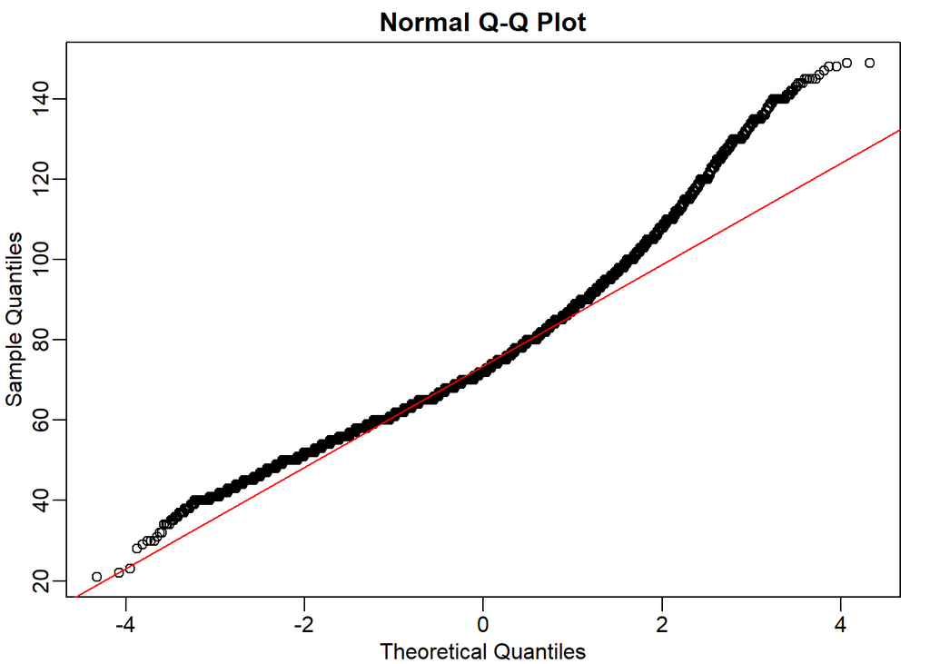

```r
mypar(1, 1)
qqnorm(dsc.clean$weight)
qqline(dsc.clean$weight, col="red")
```

Данные приближены к нормальному распределению.

### 3.3 Установим гипотезу:

H0: нет статистически значимой разницы между весом мужчин и женщин - mu = mu0

H1: есть статистически значимая разница между весом мужчины и женщины - mu != mu0

### 3.4 Разобьем исходный датасет на две выборки по полу

```r
weight.women <- dsc.clean[dsc.clean$gender==1, 3]
length(weight.women)
```

```
## [1] 42391
```

```r
weight.men <- dsc.clean[dsc.clean$gender==2, 3]
length(weight.men)
```

```
## [1] 23112
```

Исходя из данных, у нас достаточно большой обем выборок и стандартное отклонение не известно.

Следовательно используем t-кретерий. Предпологаем что выборки с разной дисперсией.

### 3.5 Посчитаем статистику d Коэна

```r
cohen.d(d=weight.men, weight.women)
```

```
##
## Cohen's d
##
## d estimate: 0.3263534 (small)
## 95 percent confidence interval:
##     lower     upper
## 0.3102300 0.3424768
```

ES = 0.3263534 то есть есть имеем слабый размер эффекта.

Зададим alpha:

```r
mu0.alpha <- 0.05
```

```r
mu0.d <- 0.3263534
```

### 3.6 Рассчитаем нужный объем выборки для мощности теста 90%.

```r
pwr.t2n.test(n1=200, n2=200, d=mu0.d, sig.level=0.05, alternative="two.sided")$power
```

```
## [1] 0.9024581
```

Необходимый размер выборки для мощности теста в 90% - по 200 наблюдений для каждой из групп.

### 3.7 С помощью функции t.test, протестируем гипотезу

Сформируем две случайные выборки по 200 наблюдений:

```r
set.seed(21)
w.w.200 <- sample(weight.women, 200)
w.w.200
```

```
##   [1]  67  60  65  97  65  85  65  62  79  45 108  61  80  65  56  64 100  85
##  [19]  89  58  64  70  72  67  78 100  70  69  80  75  68 106  57  98  71  70
##  [37]  73  56  73  86  65  74  79  55  67  84  60  69  70  60  63  70  80 117
##  [55]  59  68  65  69  68  70 105  62  65  60  96  73  60  63 100  68  83  86
##  [73]  62  73  98  79  56  78  60  75  80  78  70  80  90  75  76  46  73  89
##  [91]  90  70  90  78  73  71  57  70  93  83  93  80  68  71  84  69  80  84
## [109]  81  79  96  77  77 101  86  70  65  73  78  72  64  65  92  60  79  59
## [127]  72  56  73  94  78  80  80  84  95  54  65  54  56  78 115  68  95 103
## [145]  76  67  73  93  51  55  72  75  62  54  60  55  85  80  71  82  90  58
## [163]  70  63  80  64  74  60  91  97  62  60  55  66  70  68  73  95  75  74
## [181]  59  48  60  61  74  68  84  72  57  82  52  63  95  89  67  74  83  68
## [199]  65  93
```

```r
w.m.200 <- sample(weight.men, 200)
w.m.200
```

```
##   [1]  56  84  85  60  89 115  69  73  74  82 102  62  69  63  72  68  70  62
##  [19]  96  56  66  73  89 103  75  84  82  82  72  69  50 100  70  70  70  75
##  [37]  67  65  98  97  72  82  85  92  82  99  74  85  95  79  77  76  95  57
##  [55] 120  61  72  60  68  80  73  77 126  75  59  80  58  80  78  70  90  87
##  [73]  78  65  70  70  70  97  78  84  66  88  85  88  78  73  70  60  89  69
##  [91]  75  68  92  67  64  68  85 102 118 101  88 100  67  60  62  81  70  62
## [109]  71  70  92  86 102  80  56  75  85  61  76  96  82  68 100  64  73  61
## [127]  78  79  85  82  64  88  87  86  59  62  72  71  64  73  70  76  81  74
## [145]  72  78  66  70  85 106  79  84  59  79  75  75  68 114  80  94  67  70
## [163]  80  66  70  65  70  84  70  67  82  70  70  72  54  70  79  65 113  58
## [181]  68  79  70 122  78  57  70  69  65  86  89  60  70  86  74  76  68  74
## [199]  76  82
```

```r
t.test(w.m.200, w.w.200, alternative="two.sided")
```

```
##
##  Welch Two Sample t-test
##
## data:  w.m.200 and w.w.200
## t = 2.3687, df = 397.97, p-value = 0.01833
## alternative hypothesis: true difference in means is not equal to 0
## 95 percent confidence interval:
##  0.5543114 5.9656886
## sample estimates:
## mean of x mean of y
##     77.15     73.89
```

**Выведем размер эффекта в %:**

```r
print(mu0.d * 100)
```

```
## [1] 32.63534
```

**Выведем доверительный интервал ждя данного размера эффекта:**

```r
ci <- t.test(w.m.200, w.w.200, alternative="two.sided")$conf.int
print((ci / mean(w.w.200)) * 100)
```

```
## [1] 0.7501847 8.0737428
## attr(,"conf.level")
## [1] 0.95
```

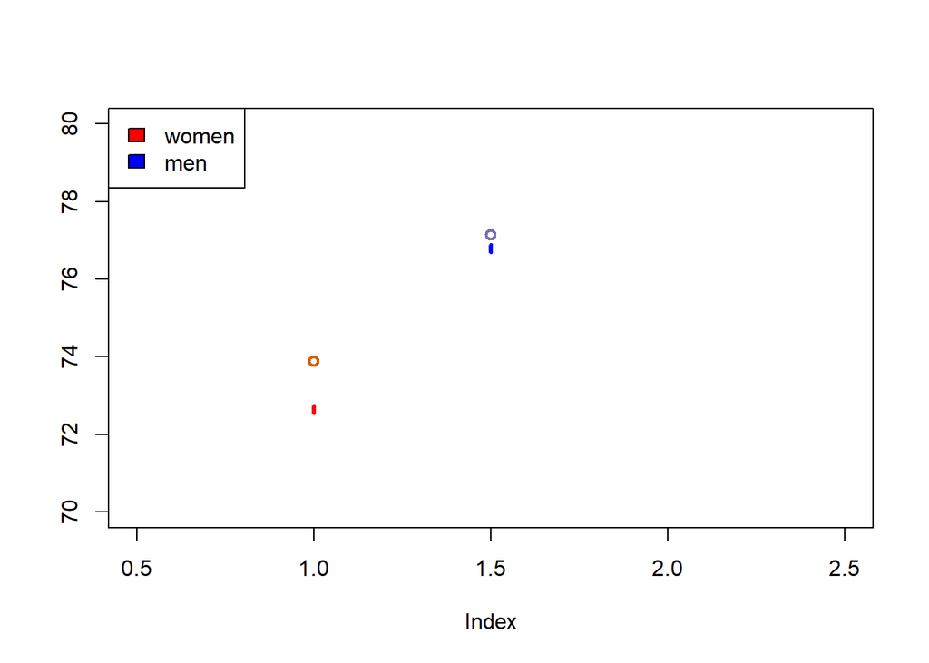

```r
plot(mean(w.w.200),col=2, lwd=2,
     xlim=c(0.5, 2.5), ylim=c(70,80),
     ylab="",
     main="")
interval=c(72.55,72.75)
lines(x=c(1,1), y=interval, col="red", lwd=3)
points(1.5, mean(w.m.200), col=3, lwd=2)
interval_1<-c(76.7,76.9)
lines(x=c(1.5,1.5), y=interval_1, col="blue", lwd=3)
legend("topleft",c("women","men"),fill=c("red","blue"))
```

### 3.8 Выводы:

Так как мы получили маленькую p-value то должны отвергнуть гипотезу H0. Но нужно учитывать что с увеличением выборки p-value будет уменьшаться.

В целом мы можем считать что иметм слабый эффект различия между весом мужчин и женщин, но сомнительно что он будет иметь какое-то научное значение на уровне генеральной выборки всей популяции.

## 4. Проведем двухфакторный дисперсионный анализ. Проверим влияние на вес, пола и приема алкоголя.

### 4.1 Выведем средние арефметические веса по подгруппам пола

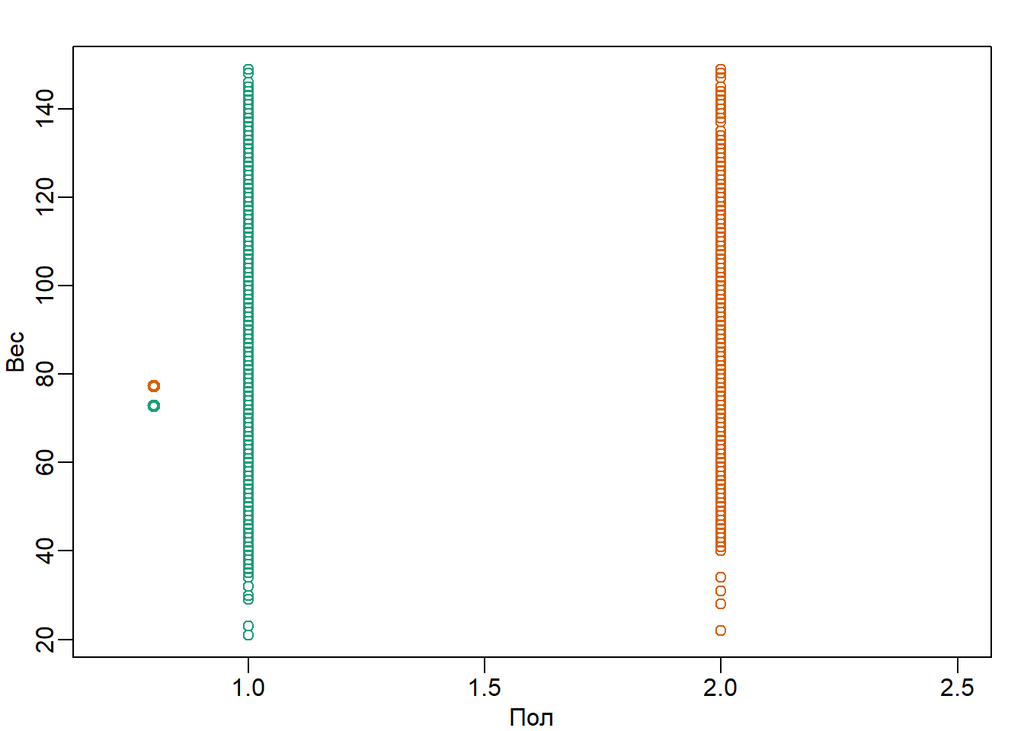

```r
mypar(1, 1)
m1.g <- mean(dsc.clean[dsc.clean$gender==1, 3])
m2.g <- mean(dsc.clean[dsc.clean$gender==2, 3])
plot(dsc.clean$gender, dsc.clean$weight, cex=1, col=dsc.clean$gender,
     xlab="Пол", ylab="Вес", xlim=c(0.7, 2.5))
points(rep(0.8, 2), c(m1.g, m2.g), col=c(1, 2), lwd=2)
```

Из рисунка видно что межгрупавая дисперсия не вилика.

Выведем средние арефметические веса по подгруппам неупотребления/потребления алкоголя.

Для удобства отображения создадим столбец alco2 в котором поменяем значения 0->1 и 1->2.

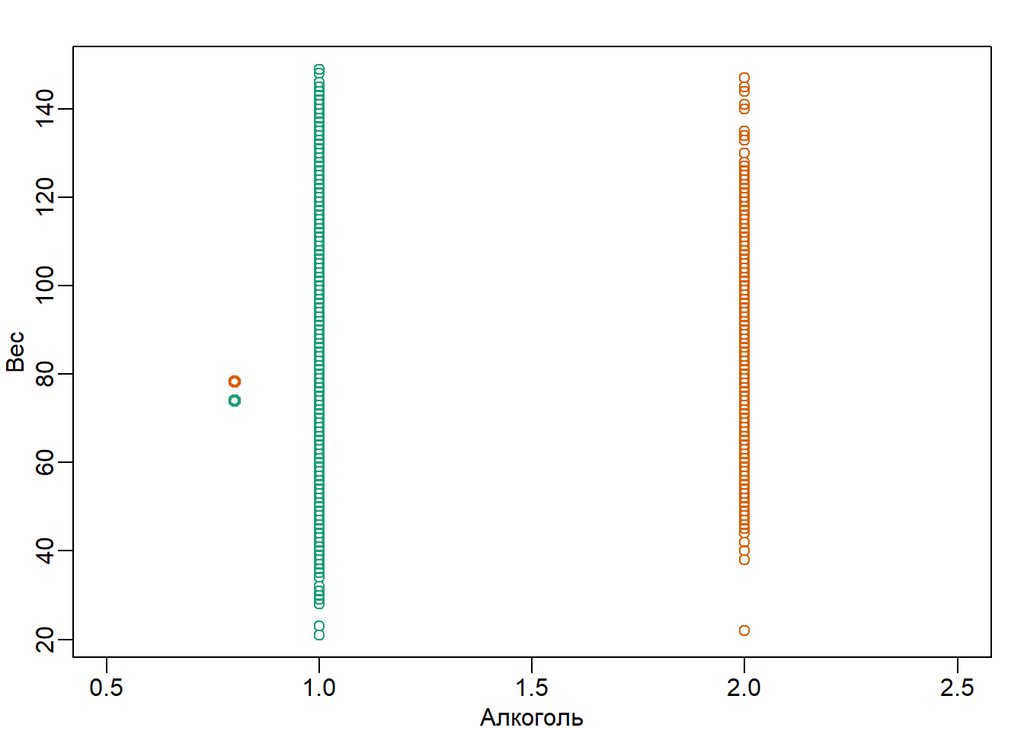

```r
mypar(1, 1)
dsc.clean$alco2 <- 0
dsc.clean$alco2[dsc.clean$alco == 0] <- 1
dsc.clean$alco2[dsc.clean$alco == 1] <- 2
m1.a <- mean(dsc.clean[dsc.clean$alco2==1, 3])
m2.a <- mean(dsc.clean[dsc.clean$alco2==2, 3])
plot(dsc.clean$alco2, dsc.clean$weight, cex=1, col=dsc.clean$alco2,
     xlab="Алкоголь", ylab="Вес", xlim=c(0.5, 2.5))
points(rep(0.8, 2), c(m1.a, m2.a), col=c(1, 2), lwd=2)
```

Из рисунка видно что межгрупавая дисперсия также не велика.

### 4.2 Проведем проверку на сбаласнсированность данных

```r
table(dsc.clean$gender)
```

```
##
##     1     2
## 42391 23112
```

```r
table(dsc.clean$alco2)
```

```
##
##     1     2
## 61996  3507
```

Наблюдения в колонках gender и alco не сбалансированы.

Так как данный имеют дисбаланс, то дисперсионный анализ становится более чувствительным к нарушениям условий его применения. Нарушение условий ведет к росту вероятности ошибки первого рода.

### 4.3 Что бы снизить вероятность ошибок первого рода создадим выборки с сбалансированным количеством наблюдений для gender и alco2 в количестве 200

```r
set.seed(21)
w1.ga1 <- sample(dsc.clean$weight[dsc.clean$gender==1 & dsc.clean$alco2==1], 200)
w2.ga1 <- sample(dsc.clean$weight[dsc.clean$gender==1 & dsc.clean$alco2==2], 200)
w1.ga2 <- sample(dsc.clean$weight[dsc.clean$gender==2 & dsc.clean$alco2==1], 200)
w2.ga2 <- sample(dsc.clean$weight[dsc.clean$gender==2 & dsc.clean$alco2==2], 200)

w.united <- c(w1.ga1, w2.ga1, w1.ga2, w2.ga2)
alco.new <- c(rep(1, 200), rep(2, 200), rep(1, 200), rep(2, 200))
gender.new <- c(rep(1, 400), rep(2, 400))
```

Создаем обьединенный датасет соблюдающий случайность и независимость:

```r
dsc.balanced <- data.frame(w.united, gender.new, alco.new)
dsc.balanced[190:210,]
```

|  | w.united | gender.new | alco.new |
| --- | --- | --- | --- |
| 190 | 80 | 1 | 1 |
| 191 | 53 | 1 | 1 |
| 192 | 65 | 1 | 1 |
| 193 | 67 | 1 | 1 |
| 194 | 53 | 1 | 1 |
| 195 | 65 | 1 | 1 |
| 196 | 80 | 1 | 1 |
| 197 | 74 | 1 | 1 |
| 198 | 67 | 1 | 1 |
| 199 | 78 | 1 | 1 |

[output cut: 11 more lines]

Получили сбалансированный датасет.

```r
table(dsc.balanced$gender.new, dsc.balanced$alco.new)
```

```
##
##       1   2
##   1 200 200
##   2 200 200
```

```r
str(dsc.balanced)
```

```
## 'data.frame':    800 obs. of  3 variables:
##  $ w.united  : num  62 86 60 72 68 82 84 96 78 66 ...
##  $ gender.new: num  1 1 1 1 1 1 1 1 1 1 ...
##  $ alco.new  : num  1 1 1 1 1 1 1 1 1 1 ...
```

### 4.4 Оценим однородность дисперсий

Воспользуемся критерием Бартлетта:

```r
bartlett.test(list(w1.ga1, w2.ga1, w1.ga2, w2.ga2))
```

```
##
##  Bartlett test of homogeneity of variances
##
## data:  list(w1.ga1, w2.ga1, w1.ga2, w2.ga2)
## Bartlett's K-squared = 5.8488, df = 3, p-value = 0.1192
```

Принимаем нулевую гипотезу на уровне значимости 0.05 .

Статистически значимых различий между дисперсиями выборок нет (p-value > 0.05).

Проверим предположение о нормальности распределений с помощью qq-графика:

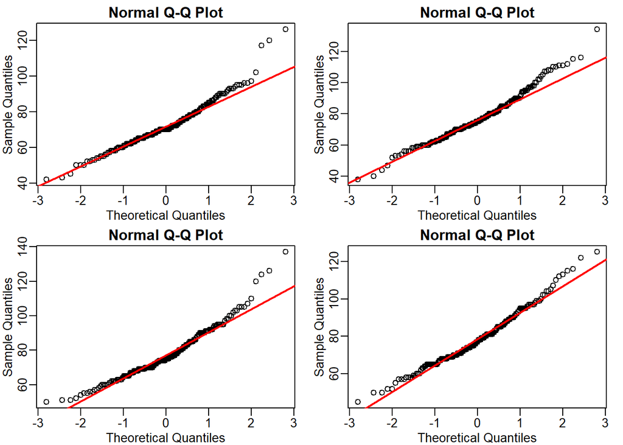

```r
mypar(2, 2)
qqnorm(w1.ga1)
qqline(w1.ga1, col="red", lwd=2)
qqnorm(w2.ga1)
qqline(w2.ga1, col="red", lwd=2)
qqnorm(w1.ga2)
qqline(w1.ga2, col="red", lwd=2)
qqnorm(w2.ga2)
qqline(w2.ga2, col="red", lwd=2)
```

Есть небольшие отклонения. Принимаем из, тем более ,что у нас одинаковые объемы выборок.

### 4.5 Выполняем дисперсионный анализ

Так как сбалансированные данные НЕ влияют на порядок включения факторов в модель:

```r
summary(aov(w.united ~ gender.new*alco.new, data=dsc.balanced))
```

```
##                      Df Sum Sq Mean Sq F value   Pr(>F)
## gender.new            1   2429  2429.0  11.894 0.000593 ***
## alco.new              1   1885  1885.0   9.230 0.002458 **
## gender.new:alco.new   1    662   662.5   3.244 0.072065 .
## Residuals           796 162558   204.2
## ---
## Signif. codes:  0 '***' 0.001 '**' 0.01 '*' 0.05 '.' 0.1 ' ' 1
```

### 4.6 Интерпретация результата

Взаимодействие факторов «пол» и «употребление алкоголя» оказывают

низкий эффект на вес пациента на уровне значимости 0.05.

Факторы «пол» и «употребление алкоголя» по отдельности оказывают более значительный эффект на вес пациента на уровне значимости 0.05.